# Week 03 - Bounding boxes, Buffers, Centroids and Spatial Joins

### Solution

```
 [1] "Oldtid"                 "Stenalder"              "Bronzealder"
 [4] "Jernalder"              "Middelalder"            "Historisk Tid"
 [7] "Vikingetid"             "Udateret"               "Nyere tid"
[10] "Efterreformatorisk tid" NA
```

```
 [1] "Gravrøse"
 [2] "Bosættelse, uspec undergruppe"
 [3] "Enkeltfund"
 [4] "Votivfund"
 [5] "Jordfæstegrav"
 [6] "Brandplet"
 [7] "Kirke"
 [8] "Kirkegård"
 [9] "Bautasten"
[10] "Gravsten"
[11] "Skåltegn"
[12] "Gravgenstand"
[13] "Brandgrav (uspecificeret type)"
[14] "Rundhøj"
[15] "Kulturlag"
```

[output cut: 61 more lines]

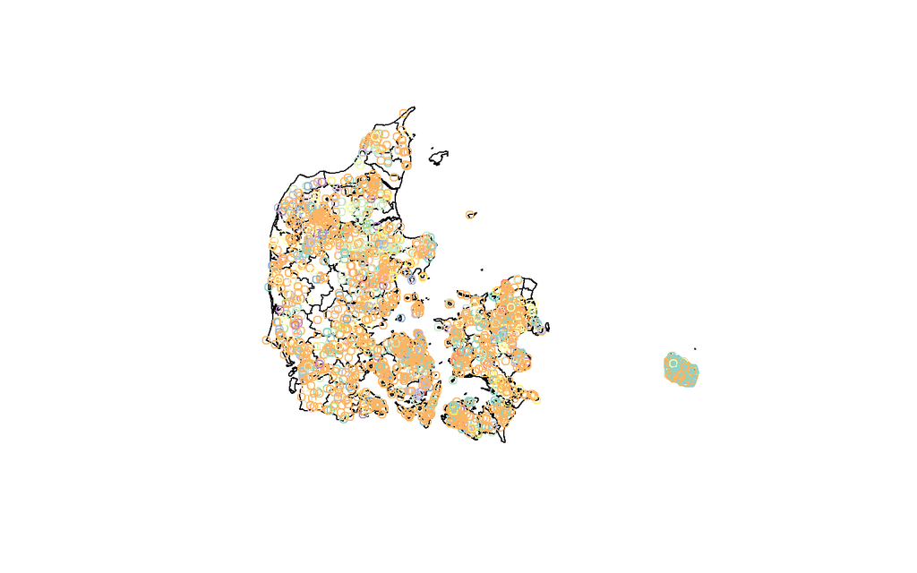

```
[1] "sf"         "tbl_df"     "tbl"        "data.frame"
```

```
Simple feature collection with 6 features and 28 fields
geometry type:  POINT
dimension:      XY
bbox:           xmin: 866209 ymin: 6114667 xmax: 882735.6 ymax: 6121528
projected CRS:  ETRS89 / UTM zone 32N
        systemnr stednr loknr sbext frednr     stednavn         stednavnsb
37010        121 060301    57  <NA>   <NA> Erlandsgaard Ejendom, gård, hus
37010.1      125 060301    52  <NA>   <NA>  Brandsgaard Ejendom, gård, hus
        anlnr anlaegstyp anlaegsbet   datering fra_aar til_aar sevaerdigh
37010       2      07046 Enkeltfund Vikingetid     750    1066         NA
37010.1     1      07190   Møntfund Vikingetid     750    1066         NA
                                                               url GID_0
37010   http://www.kulturarv.dk/fundogfortidsminder/Lokalitet/121/   DNK
37010.1 http://www.kulturarv.dk/fundogfortidsminder/Lokalitet/125/   DNK
         NAME_0   GID_1      NAME_1 NL_NAME_1     GID_2   NAME_2 VARNAME_2
37010   Denmark DNK.1_1 Hovedstaden      <NA> DNK.1.4_1 Bornholm      <NA>
37010.1 Denmark DNK.1_1 Hovedstaden      <NA> DNK.1.4_1 Bornholm      <NA>
        NL_NAME_2  TYPE_2    ENGTYPE_2 CC_2   HASC_2                 geometry
37010        <NA> Kommune Municipality <NA> DK.HS.BO POINT (868469.2 6121528)
37010.1      <NA> Kommune Municipality <NA> DK.HS.BO   POINT (866209 6120888)
 [ reached 'max' / getOption("max.print") -- omitted 4 rows ]
```

```
Simple feature collection with 90 features and 2 fields
geometry type:  GEOMETRY
dimension:      XY
bbox:           xmin: 441730 ymin: 6058610 xmax: 891909.9 ymax: 6395430
projected CRS:  ETRS89 / UTM zone 32N
# A tibble: 90 x 3
   NAME_2        n                                                      geometry
   <chr>     <int>                                              <MULTIPOINT [m]>
 1 Bornholm    464 ((863399.5 6130225), (863409.1 6120842), (863957.6 6135025),~
 2 Esbjerg     138 ((459677.8 6158605), (460001.8 6158792), (461352.8 6152241),~
 3 Thisted     134 ((453841.3 6296702), (458349.3 6292603), (458389.3 6292578),~
 4 Lolland     122 ((631289 6085859), (634435 6082976), (634787 6070269), (6349~
 5 Kertemin~   118 ((595899.6 6145718), (595928 6139726), (596167 6145665), (59~
 6 Viborg       91 ((500384.1 6259659), (501147.1 6259574), (503563.6 6262109),~
 7 Skive        85 ((483523.7 6272539), (485609.2 6273853), (487002 6271754), (~
 8 Århus        83 ((562622.4 6222394), (562728 6225047), (563569 6227175), (56~
 9 Odense       81 ((579322 6144293), (579359 6144744), (581949.4 6144339), (58~
10 Randers      77 ((551325.2 6256740), (551325.4 6256739), (551328.2 6256740),~
# ... with 80 more rows
```

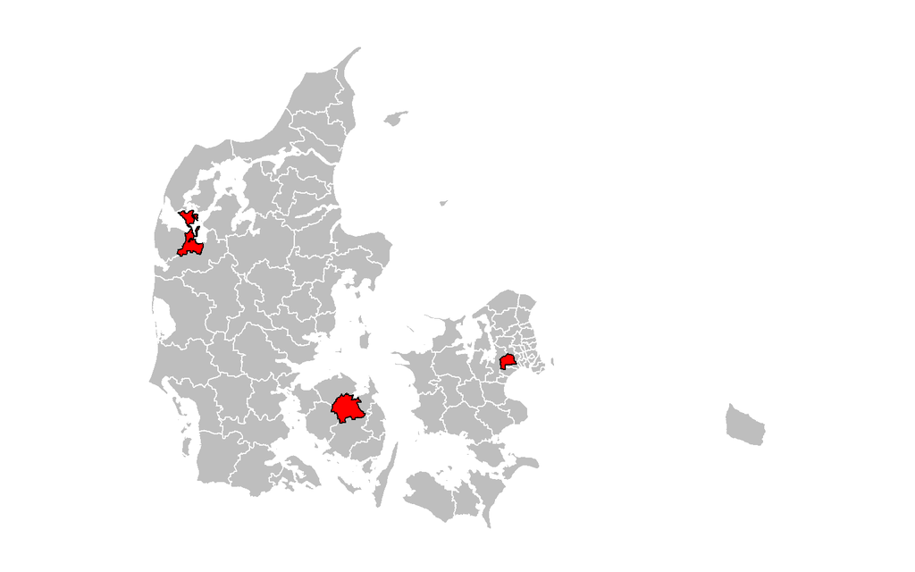

Great! The monuments object did not have municipality information until you performed the spatial join with `st_join()`. Now that the municipality information is included you can supply each municipality office with the count and coordinates of monuments they are in charge of so they can monitor and safeguard.

# Task 7: Spatial relationships

In the previous exercise, you loaded all monuments across Denmark. In this exercise you need to make a plan for family visit. Your family like to bike in green areas and visit viking monuments, so calculate:

*a) how many viking monuments are within 10000 m radius of Nobelparken and* b) how many parks are completely within this area as well.

To achieve this, you will need to select the third object in the buffer (Nobelparken) and then use `st_intersects()` to tally the monuments within 10000m radius and `st_contains()` to determine how many parks are *completely* within the buffer. You will then use the `st_intersection()` function (notice the slight difference in function name!) to **clip** the monuments and parks to the buffer.

A note about the output of functions that test relationships between two sets of features. The output of these and related functions is a special kind of list (with the class `sgbp`). For example, when using `st_intersects()`, the first element in the output can be accessed using `[[1]]`, which shows features from the monuments object that intersect with the buffer polygon. Likewise, `[[2]]` would show the buffer polygons that intersect with the monuments.

## Instructions

- Load `viking` and `parks` objects and verify consistent projection with `df_sf`
- Filter `df_sf` to Nobelparken only and create a 10000m buffer `nb_buf` around the point. There is something you will need to do before buffering!
- Use `st_intersects()` to identify `viking` that intersect with the buffer object (`nobel_buf`) and call the result `viking_int`.
- Use `st_contains()` to identify `parks` features that are completely within the buffer object (`buf`) and call the result `parks_cont`.
- Extract `viking` and parks that intersect and are contained by `nobel_buf` and save as `int` and `cont`.
- Use the `int` object you just created to identify the IDs of the monuments that intersect with buffer (the first will be XXXX).
- Use `st_intersection()` to “clip” the monuments by `nobel_buf` and call this `viking_clip`. Do the same with parks.
- Plot the result

```r
# Load objects
parks
viking


# Create a 10km buffer around Nobelparken



# Check consistent projection among the objects
________==_________
________==_________

# Identify viking monuments that intersect with the buffer
viking_int <- ___(nb_buf, viking)

# Identify parks contained by the buffer
parks_cont <- ___(nb_buf, parks)

# Get the indexes of which viking monuments intersect and which units
# are contained by the buffer
int <- viking_int[[___]]
cont <- parks_cont[[___]]

# Get the IDs or codes of the viking and parks in buffer
viking$TRAPCode[___]

# Clip the viking monuments and parks layers by the buffer (ignore the warning)
viking_clip <- ___
parks_clip <- ___

# Plot the geometry of the clipped viking monuments
plot(nb_buf$geometry[1,], border = "blue")
plot(parks[cont,], add = TRUE, col = "yellow")
plot(st_geometry(viking_clip), col = "red", add = TRUE, pch = 19)
```

### Solution

```
[1] TRUE
```

```
[1] TRUE
```

```
[1] "Uspecificeret"
[2] "Fortidsminde/lokalt kaldenavn"
[3] "Offentlige bygninger og pladser"
[4] "Ejendom, gård, hus"
[5] "Bebyggelse, havne og industrianlæg"
[6] "Vej-, gade-, o.lign., evt. nr.+ bynavn"
[7] "Beretningsnavn"
[8] "Landskab, herunder vådområde"
```

```
 [1] "Aarslev Møllepark"       "Forteparken"
 [3] "Hasselagerparken"        "Hjulbjergvejs Lokalpark"
 [5] "Holme Bypark"            "Hørgårdsparken"
 [7] "Skjoldhøjkilen"          "Skjoldhøjparken"
 [9] "Skjoldhøjskoven"         "Tilst Bypark"
[11] "Toftegårdsparken"        "Viby Park"
[13] "Æblehaven"               "Ølsted Grønning"
[15] "Åby Park"                "Åparken"
[17] "Vorrevangsparken"        "Indelukket"
[19] "Hans Broges Bakker"      "Klokkerparken"
[21] "Hjulbjergparken"         "Viby Enge"
[23] "Mølleparken"             "Marienlystparken"
[25] "Hasle Bakker"            "Præstevangen"
[27] "Mindeparken"             "Hedeskovparken"
[29] "Skt. Olof Kirkegård"     "Bådeplads - Stadevej"
[31] "Vennelystparken"         "Tangkrogen"
```

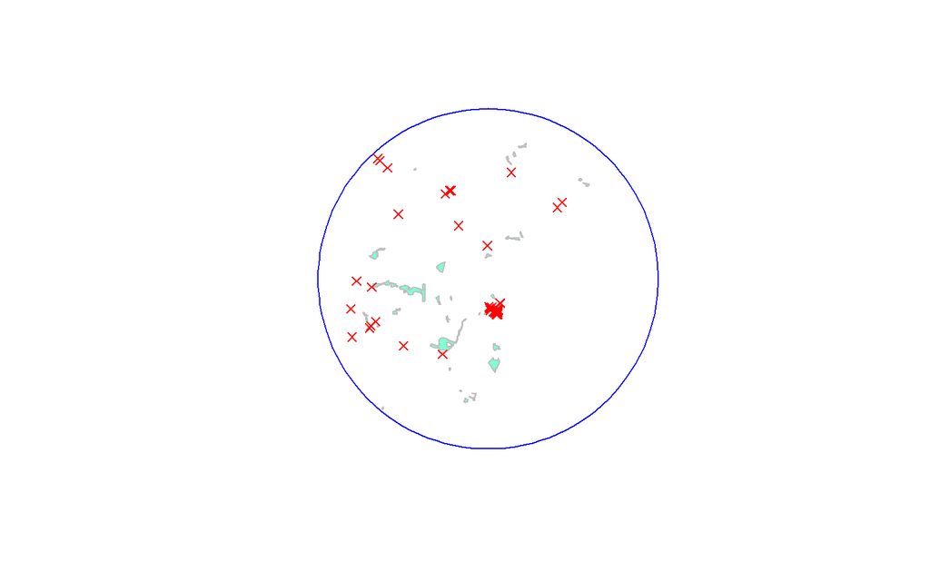

#### Questions:

1. What is the class of the object produced via `st_intersects()`?
2. Why do we use `parks[cont,]` to view the fully contained parks in the buffer plot?
3. How many parks and viking monuments respectively are there within the buffer?

The `sf` package has a lot of different functions for determining relationships. Some are easy to conflate! You have just used `st_intersects()` and `st_contains()` here but there are others as well and what you use will depend on what relationships you’re looking at. In this exercise you also used the important `st_intersection()` function to clip one layer based on another.

# Task 8: Measuring distance between features

Of course, measuring distance between feature sets is a component of spatial analysis 101 – a core skill for any analyst. There are several functions in `base` R as well as in the packages `rgeos` and `geosphere` to compute distances, but the `st_distance()` function from `sf` provides a useful feature-to-feature distance matrix as output and can be used for most distance calculation needs.

In this exercise you’ll measure the distance from the Nobelparken to the viking monuments within the 10km buffer and identify the 10 closest ones.

## Instructions

- Filter Nobelparken out of `db_sf` POINT feature and project to a planar CRS.
- Test whether the CRS of `cities` matches the CRS of the preloaded object `viking_clip` with `st_crs()`.
- Use `st_distance()` to compute the distance between Nobelparken to the viking monuments within the 10km buffer .
- Use `head()` to take a quick look at the result.
- Identify the index of the 10 sites with the smallest distance. This may take several steps that include `sort()` and `which()` functions.
- Use `nearest10` to pull out the rows from `viking` of the nearest viking monument (see the `anlaegsbet` variable).

```r
# Create the nobel object and transform to planar CRS
nobel <- ___(___)

# Test whether the CRS match
___(viking_clip) == ___(nobel)


# Compute the distance between Nobel and viking_clip
d <- ___(___, Kazanlak)


# Compute the distance between the Nobelparken and the clipped viking monuments
d <- ________(___________, nobel)

# Take a quick look at the result
________(d)

# Find the index of the 10 nearest viking monuments


# Identify the viking monuments that are the nearest, what kinds of monuments are they?
viking_clip[_________,]$anlaegsbet

# Plot the results by reruning the plot from exercise 6
```